# Shannon_et_al_reanalysis_FigS3

```python
# use scVI latent space for post integration UMAP generation
sc.pp.neighbors(adata, use_rep="X_scVI")
sc.tl.umap(adata, min_dist=0.3)
```

```
computing neighbors
    finished: added to `.uns['neighbors']`
    `.obsp['distances']`, distances for each pair of neighbors
    `.obsp['connectivities']`, weighted adjacency matrix (0:00:00)
computing UMAP
    finished: added
    'X_umap', UMAP coordinates (adata.obsm) (0:00:03)
```

```
WARNING: saving figure to file figures/umapbatch_postIntegration.svg
```

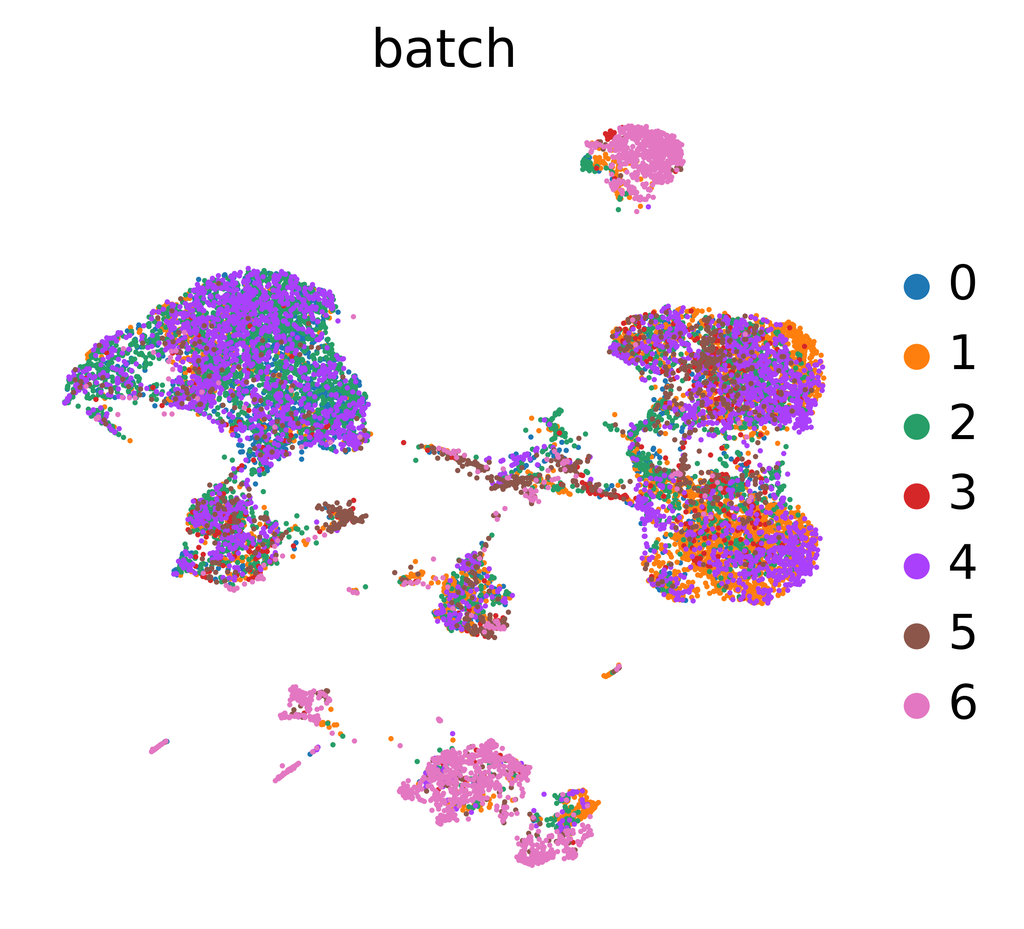

```
WARNING: saving figure to file figures/umapGA_postIntegration.svg
```

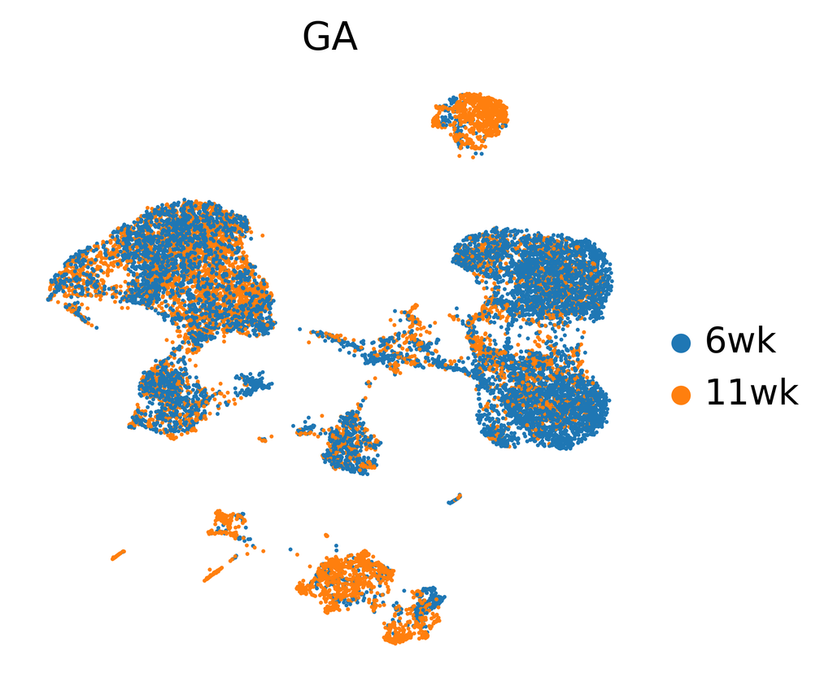

```python
sc.pl.umap(
    adata,
    color=["batch"],
    frameon=False, save="batch_postIntegration.svg")
sc.pl.umap(
    adata,
    color=["GA"],
    ncols=1,
    frameon=False,save="GA_postIntegration.svg")
```

Save the filtered data.

```python
#Save data here:
adata.write_h5ad('adata_PostIntegration.h5ad')
```

```python
#To reload data and start from this point:
adata = sc.read('adata_PostIntegration.h5ad')
```

# Clustering and Annotation

[output not shown]

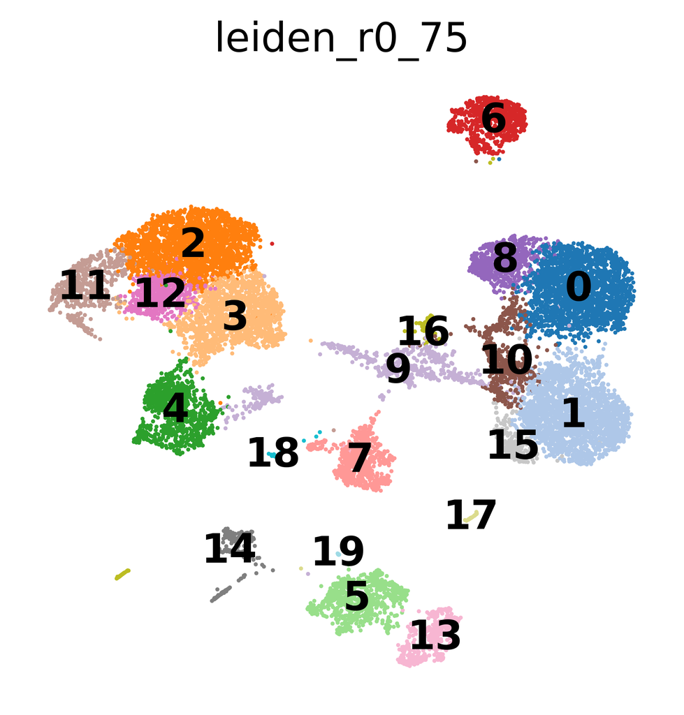

```python
sc.tl.leiden(adata, resolution=0.75, key_added='leiden_r0_75')
sc.pl.umap(adata, color=['leiden_r0_75'], palette='tab20', frameon=False,legend_loc='on data', save='all_data_clustered_FigS3a.svg')
```

Marker gene expression to eliminate non-trophoblast clusters

[output not shown]

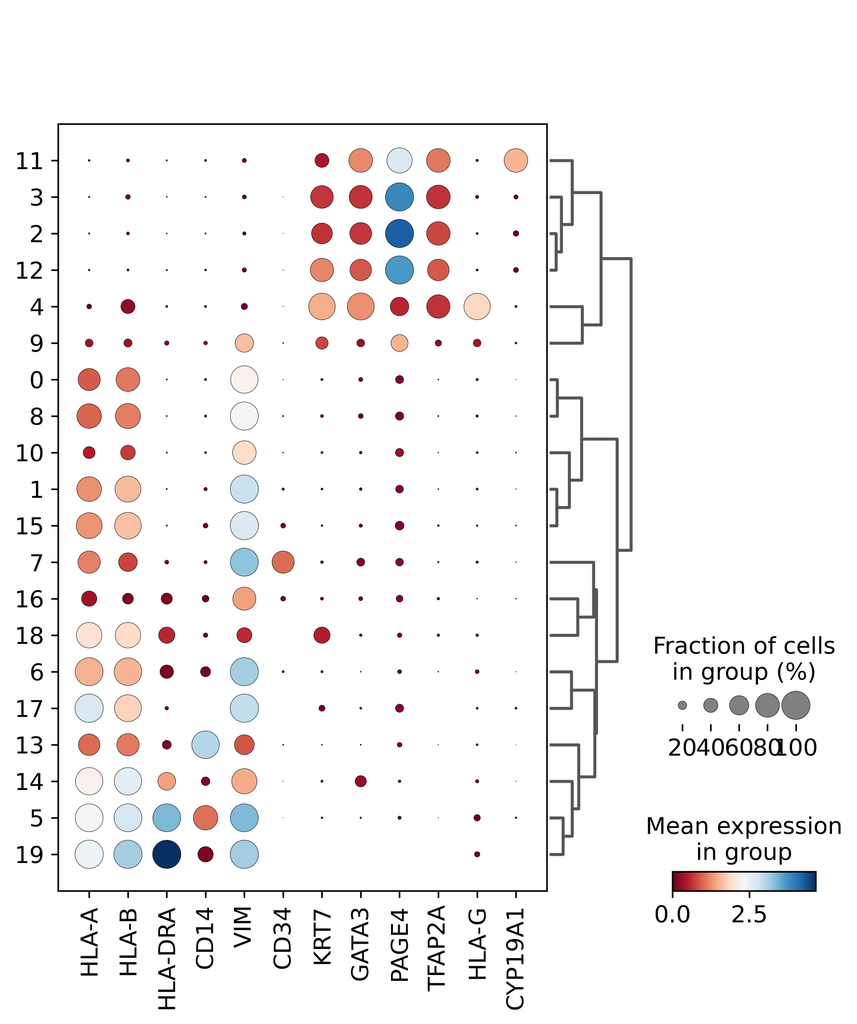

```python
sc.pl.dotplot(adata, var_names=['HLA-A','HLA-B','HLA-DRA','CD14','VIM','CD34','KRT7','GATA3','PAGE4','TFAP2A','HLA-G','CYP19A1'],
              groupby="leiden_r0_75",dendrogram=True,cmap='RdBu',save='all_data_dotplot_nonTroph_FigS3b.svg')
```

It looks like everything except for clusters 2, 3, 4, 9, 11, 12 are non-trophoblast

```python
adata_Troph = adata[adata.obs['leiden_r0_75'].isin(['2','3','4','9', '11','12'])]
```

[output not shown]

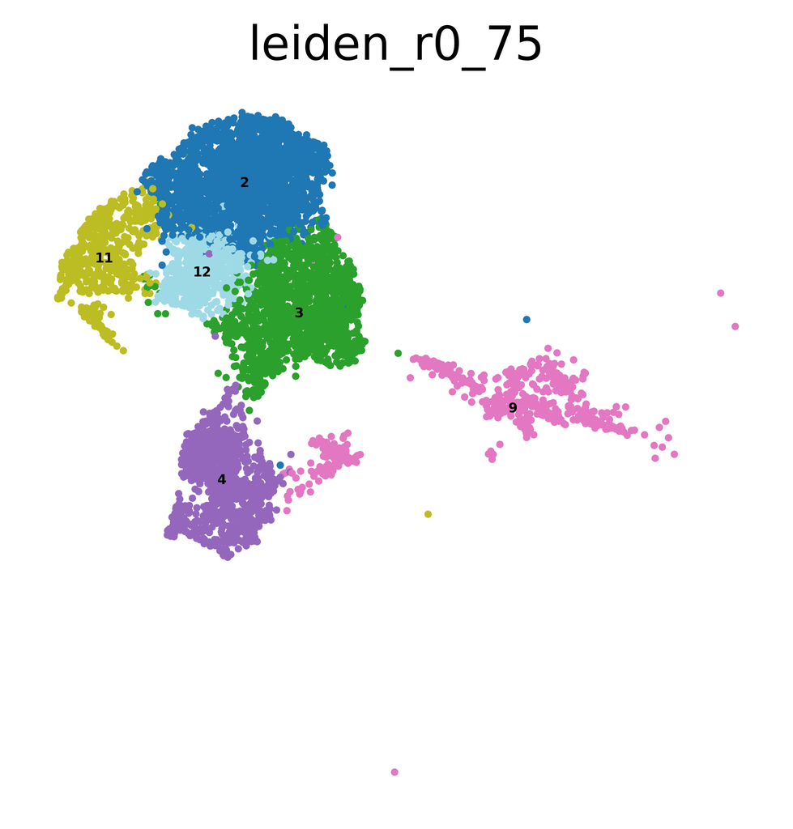

```python
sc.pl.umap(adata_Troph, color=['leiden_r0_75'], frameon=False, palette='tab20',legend_fontsize=4,legend_loc='on data')
```

```python
#Recluster
sc.pp.neighbors(adata_Troph, use_rep="X_scVI")
sc.tl.umap(adata_Troph, min_dist=0.3)
sc.tl.leiden(adata_Troph, resolution=0.75, key_added='leiden_r0_75')
```

```
computing neighbors
    finished: added to `.uns['neighbors']`
    `.obsp['distances']`, distances for each pair of neighbors
    `.obsp['connectivities']`, weighted adjacency matrix (0:00:00)
computing UMAP
    finished: added
    'X_umap', UMAP coordinates (adata.obsm) (0:00:03)
running Leiden clustering
    finished: found 11 clusters and added
    'leiden_r0_75', the cluster labels (adata.obs, categorical) (0:00:01)
```

[output not shown]

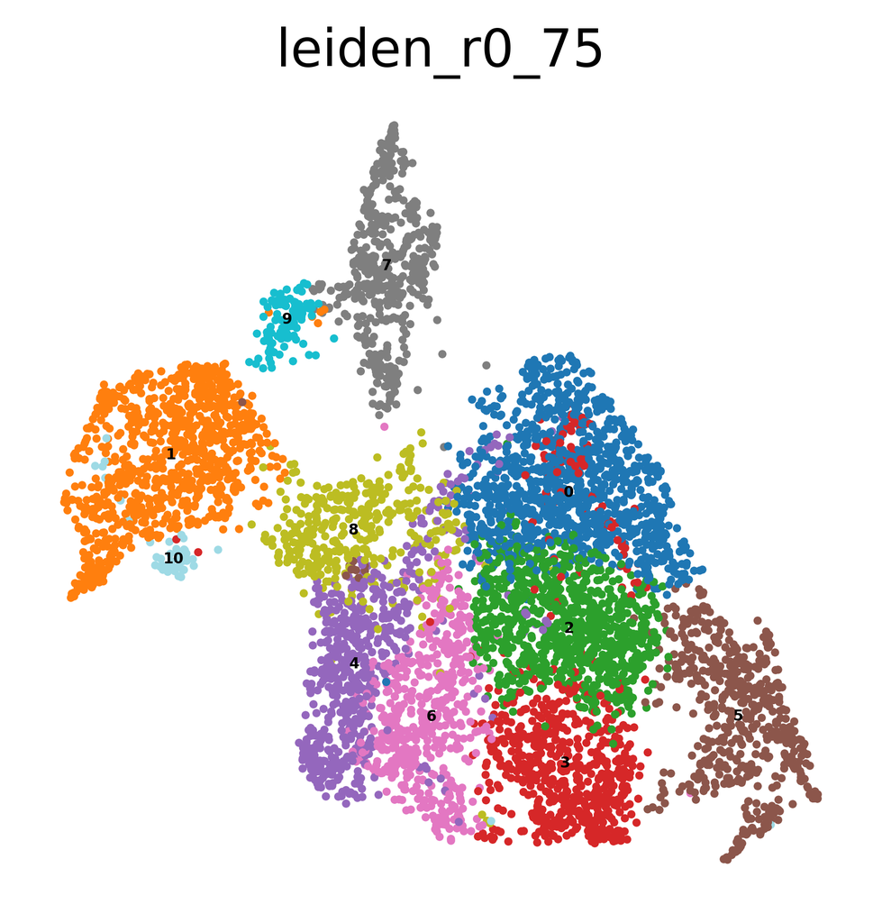

```python
sc.pl.umap(adata_Troph, color=['leiden_r0_75'], frameon=False, palette='tab20',legend_fontsize=4,legend_loc='on data')
```

```
    using 'X_pca' with n_pcs = 50
Storing dendrogram info using `.uns['dendrogram_leiden_r0_75']`
```

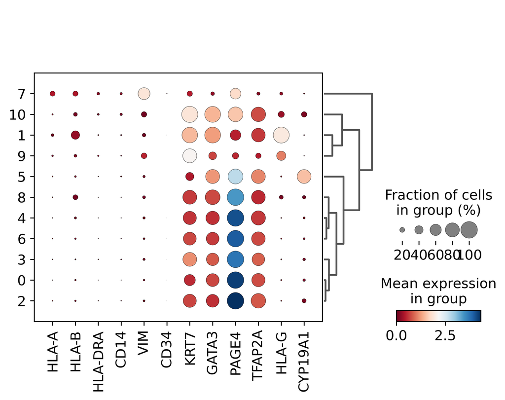

```python
sc.tl.dendrogram(adata_Troph, groupby='leiden_r0_75')
sc.pl.dotplot(adata_Troph, var_names=['HLA-A','HLA-B','HLA-DRA','CD14','VIM','CD34','KRT7','GATA3','PAGE4','TFAP2A','HLA-G','CYP19A1'],
              groupby="leiden_r0_75",dendrogram=True,cmap='RdBu')
```

[output not shown]

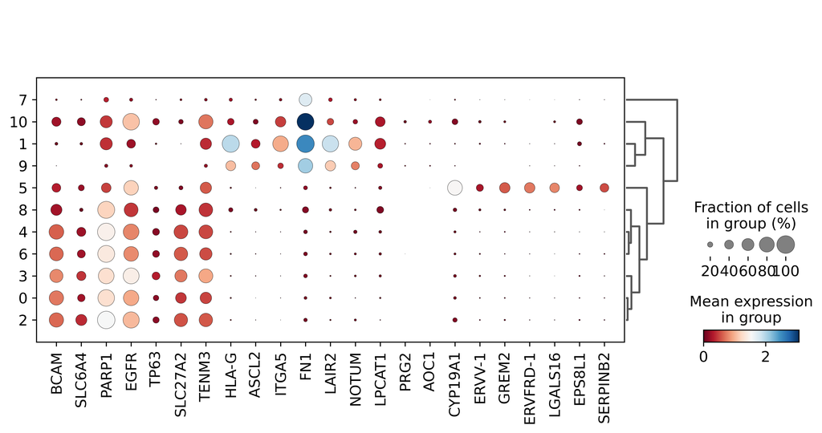

```python
sc.tl.dendrogram(adata_Troph, groupby='leiden_r0_75')
sc.pl.dotplot(adata_Troph, var_names=['BCAM','SLC6A4','PARP1','EGFR','TP63','SLC27A2','TENM3','HLA-G','ASCL2','ITGA5','FN1','LAIR2','NOTUM','LPCAT1','PRG2','AOC1',
                                      'CYP19A1','ERVV-1','GREM2','ERVFRD-1','LGALS16','EPS8L1','SERPINB2'],
              groupby="leiden_r0_75",dendrogram=True,cmap='RdBu')
```

Cluster 7 also doesn't appear to be troph so I will get rid of it as well

```python
adata_Troph = adata_Troph[adata_Troph.obs['leiden_r0_75'].isin(['0','1','2','3','4','5','6','8','9','10'])]
```

```python
#Recluster
sc.pp.neighbors(adata_Troph, use_rep="X_scVI")
sc.tl.umap(adata_Troph, min_dist=0.3)
sc.tl.leiden(adata_Troph, resolution=0.75, key_added='leiden_r0_75')
```

```
computing neighbors
    finished: added to `.uns['neighbors']`
    `.obsp['distances']`, distances for each pair of neighbors
    `.obsp['connectivities']`, weighted adjacency matrix (0:00:00)
computing UMAP
    finished: added
    'X_umap', UMAP coordinates (adata.obsm) (0:00:03)
running Leiden clustering
    finished: found 11 clusters and added
    'leiden_r0_75', the cluster labels (adata.obs, categorical) (0:00:01)
```

[output not shown]

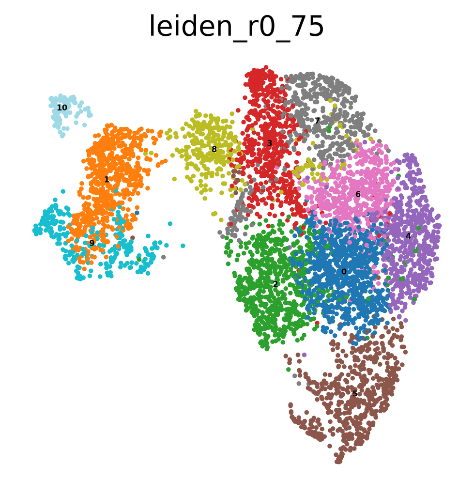

```python
sc.pl.umap(adata_Troph, color=['leiden_r0_75'], frameon=False, palette='tab20',legend_fontsize=4,legend_loc='on data')
```

[output not shown]

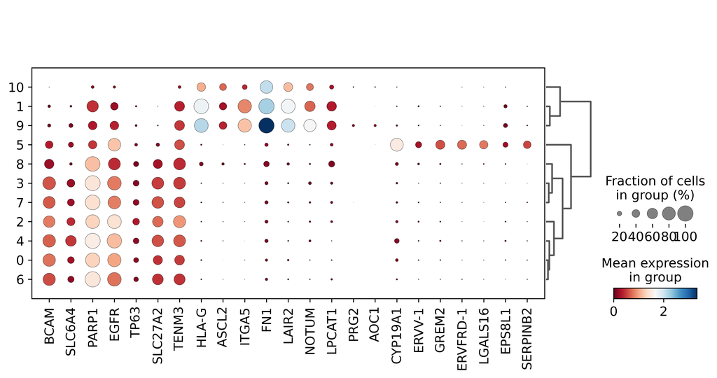

```python
sc.tl.dendrogram(adata_Troph, groupby='leiden_r0_75')
sc.pl.dotplot(adata_Troph, var_names=['BCAM','SLC6A4','PARP1','EGFR','TP63','SLC27A2','TENM3','HLA-G','ASCL2','ITGA5','FN1','LAIR2','NOTUM','LPCAT1','PRG2','AOC1',
                                      'CYP19A1','ERVV-1','GREM2','ERVFRD-1','LGALS16','EPS8L1','SERPINB2'],
              groupby="leiden_r0_75",dendrogram=True,cmap='RdBu',save='troph_only_marker_expression_filt_FigS3c.svg')
```

```python
#Calculate marker genes
sc.tl.rank_genes_groups(adata_Troph, groupby='leiden_r0_75', key_added='rank_genes_r0_75')
Troph_mark = pd.DataFrame(adata_Troph.uns['rank_genes_r0_75']['names'])
Troph_mark.head(30)
```

```
WARNING: Default of the method has been changed to 't-test' from 't-test_overestim_var'
ranking genes
    finished: added to `.uns['rank_genes_r0_75']`
    'names', sorted np.recarray to be indexed by group ids
    'scores', sorted np.recarray to be indexed by group ids
    'logfoldchanges', sorted np.recarray to be indexed by group ids
    'pvals', sorted np.recarray to be indexed by group ids
    'pvals_adj', sorted np.recarray to be indexed by group ids (0:00:00)
```

|  | 0 | 1 | 2 | 3 | 4 | 5 | 6 | 7 | 8 | 9 | 10 |
| --- | --- | --- | --- | --- | --- | --- | --- | --- | --- | --- | --- |
| 0 | PAGE4 | TPM1 | PEG10 | PCNA | PAGE4 | CGA | PAGE4 | STMN1 | ENO1 | TPM1 | KRT19 |
| 1 | RPL34 | KRT19 | FBN2 | H2AFZ | IFI6 | TBX3 | RPS15A | HMGB1 | TUBA1B | KRT19 | ACTB |
| 2 | RPLP1 | SLC16A3 | MT-CO3 | HMGB2 | SMAGP | MALAT1 | RPL13A | HMGB2 | NPM1 | FN1 | TPM1 |
| 3 | RPS28 | TFPI | MT-ND3 | TUBA1B | MGST3 | RP11-266L9.2 | RPL10A | PTTG1 | H2AFZ | QSOX1 | IGF2 |
| 4 | RPS12 | HAPLN3 | DUSP9 | CALM2 | EFEMP1 | SLC40A1 | RPL7A | ARL6IP1 | RAN | KRT8 | FN1 |
| 5 | RPL31 | TAGLN2 | PEG3 | TUBB | PEG10 | INSL4 | RPS27A | TUBA1B | RPS9 | CALD1 | FSTL3 |
| 6 | RPL27A | QSOX1 | MT-ND2 | STMN1 | COMT | ANXA1 | RPS3 | CALM2 | LDHA | ITGB1 | KRT7 |
| 7 | RPS23 | CD63 | MT-CYB | HMGB1 | ATP5L | CSF3R | RPL15 | HMGN2 | PTMA | COL4A2 | IGFBP3 |
| 8 | RPL26 | KRT8 | MT-ATP6 | DUT | SPINT2 | TAX1BP1 | RPS8 | CENPF | SNRPE | TFPI | PPP1R14B |
| 9 | RPS15A | DIO2 | MT-ND4 | HIST1H4C | LDHB | KRT23 | RPS23 | PEG10 | PA2G4 | LAPTM4A | GAPDH |
| 10 | RPS25 | HLA-G | MT-CO2 | GGCT | FXYD3 | SQSTM1 | RPL7 | MT2A | HSP90AB1 | MFAP5 | TUBA1C |
| 11 | RPS14 | PGF | MT-ND1 | NASP | VGLL1 | CYP19A1 | RPS12 | H2AFZ | RPL35A | SLC16A3 | CDKN1C |
| 12 | RPS27 | MFAP5 | SLC26A2 | PAGE4 | PNP | TOP1 | RPS5 | TOP2A | TUBB | HLA-G | CCNE1 |
| 13 | RPS29 | FN1 | MT-CO1 | CDK1 | OLR1 | GADD45G | RPS7 | BIRC5 | SERBP1 | COL4A1 | LGALS1 |
| 14 | RPL39 | CALD1 | GNAS | KIAA0101 | SERPINF1 | CLIP1 | RPS6 | PTMA | SNRPD1 | LIMA1 | COL3A1 |
| 15 | RPS8 | EFNA1 | ACSS1 | HELLS | GSTP1 | S100P | RPS3A | NUCKS1 | RANBP1 | PTPRF | TFPI |
| 16 | IFI6 | SRI | FBN1 | ZWINT | VAMP8 | ERVW-1 | RPL3 | CCNB2 | RPL19 | FSTL3 | YBX1 |
| 17 | RPS18 | LY6E | EGFR | CKS1B | MPP1 | UBE2B | RPS19 | PAGE4 | RPS5 | P4HB | COTL1 |
| 18 | RPL32 | HSPA2 | DDB1 | UBE2T | ALDH7A1 | PRKCZ | NDUFA4 | CDC20 | TIMM13 | EFNA1 | CGA |
| 19 | RPL30 | LAIR2 | GPR56 | GMNN | NGFRAP1 | MUC15 | RPL13 | NUSAP1 | NCL | IGFBP3 | ASCL2 |
| 20 | RPS19 | COL4A1 | APLP2 | NAP1L1 | S100A6 | ST3GAL4 | RPL27A | CDKN3 | LY6E | FLNB | LAIR2 |
| 21 | RPS20 | COL4A2 | LAMA5 | DEK | PARP1 | GDF15 | RPS15 | HNRNPA2B1 | RPL6 | TAGLN2 | CCNB1 |
| 22 | RPL13A | FSTL3 | TIMP3 | DHFR | MPC2 | SECISBP2L | RPL19 | HSP90AA1 | RPL5 | CD63 | VGLL3 |
| 23 | RPL10 | PDIA6 | YAP1 | RPA3 | PHLDA2 | HSPB8 | RPL18A | CCNA2 | CYCS | CALU | ADAM12 |
| 24 | RPL12 | GLRX | TBL1X | PRC1 | CLTA | NEAT1 | RPS18 | HMMR | RPS3A | LAIR2 | TMSB10 |
| 25 | RPLP2 | ACTB | JUN | ORC6 | ANXA5 | COBLL1 | BTF3 | RAD21 | RPL36 | DIO2 | HLA-G |
| 26 | RPL18 | ARHGDIB | NFE2L3 | SLC25A6 | SMS | TMEM40 | RPL30 | HNRNPR | UQCRH | KLF6 | LDHA |
| 27 | RPL13 | SLC2A3 | MSI2 | MCM3 | WBP5 | NUCB2 | RPS16 | CKS1B | NME1 | ADAM12 | DLK1 |
| 28 | RPS27A | APOC1 | SPINT1 | WDR34 | FAM3B | PAPOLA | RPL8 | SMC4 | RPS15 | ITGA5 | DIO2 |
| 29 | COX7C | LDHA | MALAT1 | TK1 | ITIH5 | ZNF292 | RPL28 | KPNA2 | RPL18A | PGF | C12orf75 |

```python
#write this marker list to a file
Troph_mark.head(200).to_csv('Troph_recluster_marker_genes_leiden_r0_75.csv')
```

```python
#Save data here:
adata_Troph.write_h5ad('adata_Troph_PostTroph_filt.h5ad')
```

# Annotate clusters

```python
adata_noTSC = adata_Troph
```

Using the markers, clusters were annotated using broad trophoblast categories

[output not shown]

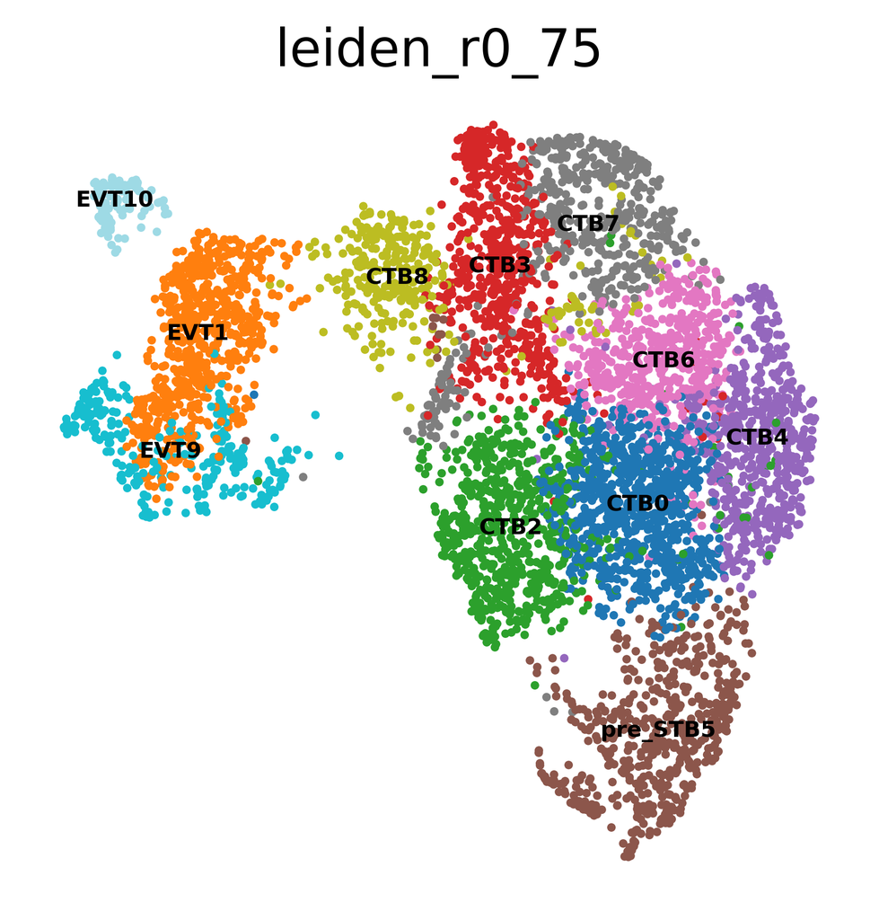

```python
cluster_names = ['CTB0', 'EVT1', 'CTB2', 'CTB3', 'CTB4','pre_STB5','CTB6','CTB7','CTB8','EVT9','EVT10']
adata_noTSC.rename_categories('leiden_r0_75', cluster_names)
sc.pl.umap(adata_noTSC, color=['leiden_r0_75'], frameon=False, palette='tab20',legend_fontsize=6,legend_loc='on data',save='troph_only_umap_reclustered_named_FigS3d.svg')
```

```python
#Save data here:
adata_noTSC.write_h5ad('adata_noTSC_trophOnly.h5ad')
```

```python
adata_noTSC.shape
```

```
(5596, 25341)
```

```python
#Examine the metadata of each cluster
pd.crosstab(adata_noTSC.obs['GA'], adata_noTSC.obs['leiden_r0_75'])
```

| leiden_r0_75 GA | CTB0 | EVT1 | CTB2 | CTB3 | CTB4 | pre_STB5 | CTB6 | CTB7 | CTB8 | EVT9 | EVT10 |
| --- | --- | --- | --- | --- | --- | --- | --- | --- | --- | --- | --- |
| 6wk | 334 | 352 | 307 | 195 | 351 | 181 | 146 | 182 | 113 | 138 | 102 |
| 11wk | 495 | 298 | 342 | 433 | 233 | 375 | 366 | 301 | 207 | 136 | 9 |

```python
#Examine the metadata of each cluster
pd.crosstab(adata_noTSC.obs['sex'], adata_noTSC.obs['leiden_r0_75'])
```

| leiden_r0_75 sex | CTB0 | EVT1 | CTB2 | CTB3 | CTB4 | pre_STB5 | CTB6 | CTB7 | CTB8 | EVT9 | EVT10 |
| --- | --- | --- | --- | --- | --- | --- | --- | --- | --- | --- | --- |
| female | 215 | 195 | 173 | 236 | 194 | 131 | 205 | 174 | 162 | 138 | 28 |
| male | 614 | 455 | 476 | 392 | 390 | 425 | 307 | 309 | 158 | 136 | 83 |

```python
#Examine the metadata of each cluster
pd.crosstab(adata_noTSC.obs['patient'], adata_noTSC.obs['leiden_r0_75'])
```

| leiden_r0_75 patient | CTB0 | EVT1 | CTB2 | CTB3 | CTB4 | pre_STB5 | CTB6 | CTB7 | CTB8 | EVT9 | EVT10 |
| --- | --- | --- | --- | --- | --- | --- | --- | --- | --- | --- | --- |
| P21 | 183 | 48 | 100 | 210 | 46 | 84 | 179 | 131 | 144 | 42 | 3 |
| P89 | 30 | 97 | 60 | 23 | 134 | 31 | 24 | 25 | 11 | 44 | 7 |
| P130 | 312 | 250 | 239 | 221 | 179 | 280 | 187 | 164 | 63 | 70 | 3 |
| P244 | 2 | 50 | 10 | 1 | 6 | 5 | 2 | 12 | 7 | 28 | 15 |
| P277 | 300 | 159 | 208 | 162 | 195 | 125 | 116 | 135 | 83 | 47 | 5 |
| P295 | 2 | 46 | 29 | 9 | 16 | 20 | 4 | 10 | 12 | 19 | 75 |
| P899 | 0 | 0 | 3 | 2 | 8 | 11 | 0 | 6 | 0 | 24 | 3 |

```python
#Recalculate marker genes
sc.tl.rank_genes_groups(adata_noTSC, groupby='leiden_r0_75', key_added='rank_genes_r0_75_combined')
noTSC_mark_combo = pd.DataFrame(adata_noTSC.uns['rank_genes_r0_75_combined']['names'])
noTSC_mark_combo.head(30)
```

```
WARNING: Default of the method has been changed to 't-test' from 't-test_overestim_var'
ranking genes
    finished: added to `.uns['rank_genes_r0_75_combined']`
    'names', sorted np.recarray to be indexed by group ids
    'scores', sorted np.recarray to be indexed by group ids
    'logfoldchanges', sorted np.recarray to be indexed by group ids
    'pvals', sorted np.recarray to be indexed by group ids
    'pvals_adj', sorted np.recarray to be indexed by group ids (0:00:00)
```

|  | CTB0 | EVT1 | CTB2 | CTB3 | CTB4 | pre_STB5 | CTB6 | CTB7 | CTB8 | EVT9 | EVT10 |
| --- | --- | --- | --- | --- | --- | --- | --- | --- | --- | --- | --- |
| 0 | PAGE4 | TPM1 | PEG10 | PCNA | PAGE4 | CGA | PAGE4 | STMN1 | ENO1 | TPM1 | KRT19 |
| 1 | RPL34 | KRT19 | FBN2 | H2AFZ | IFI6 | TBX3 | RPS15A | HMGB1 | TUBA1B | KRT19 | ACTB |
| 2 | RPLP1 | SLC16A3 | MT-CO3 | HMGB2 | SMAGP | MALAT1 | RPL13A | HMGB2 | NPM1 | FN1 | TPM1 |
| 3 | RPS28 | TFPI | MT-ND3 | TUBA1B | MGST3 | RP11-266L9.2 | RPL10A | PTTG1 | H2AFZ | QSOX1 | IGF2 |
| 4 | RPS12 | HAPLN3 | DUSP9 | CALM2 | EFEMP1 | SLC40A1 | RPL7A | ARL6IP1 | RAN | KRT8 | FN1 |
| 5 | RPL31 | TAGLN2 | PEG3 | TUBB | PEG10 | INSL4 | RPS27A | TUBA1B | RPS9 | CALD1 | FSTL3 |
| 6 | RPL27A | QSOX1 | MT-ND2 | STMN1 | COMT | ANXA1 | RPS3 | CALM2 | LDHA | ITGB1 | KRT7 |
| 7 | RPS23 | CD63 | MT-CYB | HMGB1 | ATP5L | CSF3R | RPL15 | HMGN2 | PTMA | COL4A2 | IGFBP3 |
| 8 | RPL26 | KRT8 | MT-ATP6 | DUT | SPINT2 | TAX1BP1 | RPS8 | CENPF | SNRPE | TFPI | PPP1R14B |
| 9 | RPS15A | DIO2 | MT-ND4 | HIST1H4C | LDHB | KRT23 | RPS23 | PEG10 | PA2G4 | LAPTM4A | GAPDH |
| 10 | RPS25 | HLA-G | MT-CO2 | GGCT | FXYD3 | SQSTM1 | RPL7 | MT2A | HSP90AB1 | MFAP5 | TUBA1C |
| 11 | RPS14 | PGF | MT-ND1 | NASP | VGLL1 | CYP19A1 | RPS12 | H2AFZ | RPL35A | SLC16A3 | CDKN1C |
| 12 | RPS27 | MFAP5 | SLC26A2 | PAGE4 | PNP | TOP1 | RPS5 | TOP2A | TUBB | HLA-G | CCNE1 |
| 13 | RPS29 | FN1 | MT-CO1 | CDK1 | OLR1 | GADD45G | RPS7 | BIRC5 | SERBP1 | COL4A1 | LGALS1 |
| 14 | RPL39 | CALD1 | GNAS | KIAA0101 | SERPINF1 | CLIP1 | RPS6 | PTMA | SNRPD1 | LIMA1 | COL3A1 |
| 15 | RPS8 | EFNA1 | ACSS1 | HELLS | GSTP1 | S100P | RPS3A | NUCKS1 | RANBP1 | PTPRF | TFPI |
| 16 | IFI6 | SRI | FBN1 | ZWINT | VAMP8 | ERVW-1 | RPL3 | CCNB2 | RPL19 | FSTL3 | YBX1 |
| 17 | RPS18 | LY6E | EGFR | CKS1B | MPP1 | UBE2B | RPS19 | PAGE4 | RPS5 | P4HB | COTL1 |
| 18 | RPL32 | HSPA2 | DDB1 | UBE2T | ALDH7A1 | PRKCZ | NDUFA4 | CDC20 | TIMM13 | EFNA1 | CGA |
| 19 | RPL30 | LAIR2 | GPR56 | GMNN | NGFRAP1 | MUC15 | RPL13 | NUSAP1 | NCL | IGFBP3 | ASCL2 |
| 20 | RPS19 | COL4A1 | APLP2 | NAP1L1 | S100A6 | ST3GAL4 | RPL27A | CDKN3 | LY6E | FLNB | LAIR2 |
| 21 | RPS20 | COL4A2 | LAMA5 | DEK | PARP1 | GDF15 | RPS15 | HNRNPA2B1 | RPL6 | TAGLN2 | CCNB1 |
| 22 | RPL13A | FSTL3 | TIMP3 | DHFR | MPC2 | SECISBP2L | RPL19 | HSP90AA1 | RPL5 | CD63 | VGLL3 |
| 23 | RPL10 | PDIA6 | YAP1 | RPA3 | PHLDA2 | HSPB8 | RPL18A | CCNA2 | CYCS | CALU | ADAM12 |
| 24 | RPL12 | GLRX | TBL1X | PRC1 | CLTA | NEAT1 | RPS18 | HMMR | RPS3A | LAIR2 | TMSB10 |
| 25 | RPLP2 | ACTB | JUN | ORC6 | ANXA5 | COBLL1 | BTF3 | RAD21 | RPL36 | DIO2 | HLA-G |
| 26 | RPL18 | ARHGDIB | NFE2L3 | SLC25A6 | SMS | TMEM40 | RPL30 | HNRNPR | UQCRH | KLF6 | LDHA |
| 27 | RPL13 | SLC2A3 | MSI2 | MCM3 | WBP5 | NUCB2 | RPS16 | CKS1B | NME1 | ADAM12 | DLK1 |
| 28 | RPS27A | APOC1 | SPINT1 | WDR34 | FAM3B | PAPOLA | RPL8 | SMC4 | RPS15 | ITGA5 | DIO2 |
| 29 | COX7C | LDHA | MALAT1 | TK1 | ITIH5 | ZNF292 | RPL28 | KPNA2 | RPL18A | PGF | C12orf75 |

```python
#write this marker list to a file
noTSC_mark_combo.head(200).to_csv('troph_only_umap_reclustered_named_marker_genes_leiden_r0_75.csv')
```

Determine the cell density for the two different gestational ages

[output not shown]

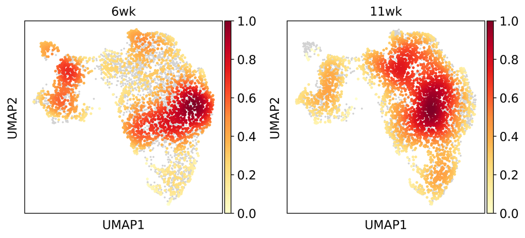

```python
sc.tl.embedding_density(adata_noTSC, basis='umap', groupby='GA')
sc.pl.embedding_density(adata_noTSC, basis='umap', key='umap_density_GA', group=['6wk','11wk'],ncols=3,bg_dotsize=20, fg_dotsize=40,save='troph_only_6_11wk_embed_FigS3e.svg')
```

```python
#Calculate marker genes of CTB6(11wk) vs CTB4(6wk)
sc.tl.rank_genes_groups(adata_noTSC, groupby='leiden_r0_75',groups=['CTB6'],reference='CTB4', key_added='CTB6_11wk_vs_CTB4_6wk')
CTB6_v_CTB4 = sc.get.rank_genes_groups_df(adata_noTSC, group=None,key='CTB6_11wk_vs_CTB4_6wk')
#going to write this to a file so that I have it
CTB6_v_CTB4.head(500).to_csv('CTB6_11wk_vs_CTB4_6wk_trophOnly.csv')
CTB6_v_CTB4.head(10)
```

```
WARNING: Default of the method has been changed to 't-test' from 't-test_overestim_var'
ranking genes
    finished: added to `.uns['CTB6_11wk_vs_CTB4_6wk']`
    'names', sorted np.recarray to be indexed by group ids
    'scores', sorted np.recarray to be indexed by group ids
    'logfoldchanges', sorted np.recarray to be indexed by group ids
    'pvals', sorted np.recarray to be indexed by group ids
    'pvals_adj', sorted np.recarray to be indexed by group ids (0:00:00)
```

|  | names | scores | logfoldchanges | pvals | pvals_adj |
| --- | --- | --- | --- | --- | --- |
| 0 | RPS3 | 21.734364 | 0.583751 | 2.023003e-86 | 2.563246e-82 |
| 1 | RPS6 | 20.797480 | 0.586654 | 1.181912e-79 | 9.983611e-76 |
| 2 | RPS18 | 20.627842 | 0.533817 | 2.546055e-79 | 1.612990e-75 |
| 3 | RPL28 | 19.820690 | 0.594677 | 1.974650e-74 | 8.339936e-71 |
| 4 | RPL8 | 19.738251 | 0.525162 | 6.867772e-74 | 2.175453e-70 |
| 5 | RPL7A | 19.695072 | 0.541987 | 6.421521e-74 | 2.175453e-70 |
| 6 | RPS15 | 19.294424 | 0.527525 | 4.390557e-70 | 1.236234e-66 |
| 7 | RPL36 | 19.024605 | 0.581860 | 1.644531e-69 | 3.788550e-66 |
| 8 | NPM1 | 18.853516 | 0.681874 | 7.694574e-69 | 1.624902e-65 |
| 9 | RPS23 | 18.774935 | 0.458111 | 8.108456e-68 | 1.580588e-64 |

```python
#Now do the same thing but the other way around
#Calculate marker genes of CTB4(6wk) vs CTB6(11wk)
sc.tl.rank_genes_groups(adata_noTSC, groupby='leiden_r0_75',groups=['CTB4'],reference='CTB6', key_added='CTB4_6wk_vs_CTB6_11wk')
CTB4_v_CTB6 = sc.get.rank_genes_groups_df(adata_noTSC, group=None,key='CTB4_6wk_vs_CTB6_11wk')
#going to write this to a file so that I have it
CTB4_v_CTB6.head(500).to_csv('CTB4_6wk_vs_CTB6_11wk_trophOnly.csv')
CTB4_v_CTB6.head(10)
```

```
WARNING: Default of the method has been changed to 't-test' from 't-test_overestim_var'
ranking genes
    finished: added to `.uns['CTB4_6wk_vs_CTB6_11wk']`
    'names', sorted np.recarray to be indexed by group ids
    'scores', sorted np.recarray to be indexed by group ids
    'logfoldchanges', sorted np.recarray to be indexed by group ids
    'pvals', sorted np.recarray to be indexed by group ids
    'pvals_adj', sorted np.recarray to be indexed by group ids (0:00:00)
```

|  | names | scores | logfoldchanges | pvals | pvals_adj |
| --- | --- | --- | --- | --- | --- |
| 0 | MALAT1 | 25.788433 | 1.168780 | 6.666790e-115 | 1.689431e-110 |
| 1 | INSL4 | 20.044209 | 2.360685 | 5.008841e-75 | 2.538581e-71 |
| 2 | PHLDA2 | 19.060335 | 1.327528 | 5.073711e-70 | 1.285729e-66 |
| 3 | CSF3R | 18.286480 | 1.413588 | 2.172053e-65 | 3.237764e-62 |
| 4 | IFI6 | 17.470596 | 0.615552 | 1.958749e-60 | 2.068194e-57 |
| 5 | ITIH5 | 16.247398 | 1.305751 | 2.436825e-53 | 1.929737e-50 |
| 6 | EFEMP1 | 16.060503 | 0.853380 | 2.826378e-52 | 2.046379e-49 |
| 7 | OLR1 | 15.707226 | 1.160154 | 2.939707e-50 | 1.910131e-47 |
| 8 | ATP2B1 | 14.836079 | 1.323413 | 1.702780e-45 | 9.588922e-43 |
| 9 | TINAGL1 | 14.544158 | 1.291685 | 7.444170e-44 | 3.772854e-41 |

```python
#Save data here:
adata_noTSC.write_h5ad('adata_noTSC_trophOnly.h5ad')
```